# Calculating telemetry effort

**Goal**

Due to missing data, it is not possible to calculate observation effort at level of individual bird; here, I calculate telemetry observation effort for each site and date.

However, even this is a little bit tricky, because sometimes observation start and end times were not recorded. Here, I estimate observation effort based on the available data. Ultimately, this approach seems to work OK; estimated times are pretty close to the times recorded in the field.

## Step 1: Import data and functions

```r
#Telemetry data
telem_data <- read.csv("../../data/export/intermediate/Telemetry_data_2016-2018_time_at_location.csv") %>%
  mutate(date = lubridate::ymd(date))

#Experiment info. Will add to observation effort
exp_info <- read.csv("../../data/import/data/Experiment_dates_2016-2018.csv") %>%
  select(year, patch, control_treatment, date, exp_phase, priority = video_priority) %>%
  mutate(date = lubridate::mdy(date))

#Get observation effort data (originally compiled by hand in Dec 2018)
obs_effort <- read.csv("../../data/import/data/telemetry/Telemetry_effort_time_per_bird_20211214.csv") %>%
  mutate(date = lubridate::mdy(date)) #Will convert to ymd in later step

#Functions
source("../../code/helper_functions/Calculate_basic_summary_stats.R")
```

## Step 2: Calculate observation effort

Prepare effort data

```r
#1. Remove rows where 'bird_found' = 'yes_presence_only' (from when people scanned for signal) because there are no GPS points in telemetry data for these efforts
#2. Combine date and time into one column
#3. Convert to long form in order to remove missing data from start and end time independently
obs_effort <- obs_effort %>%
  filter(bird_found != "yes_presence_only") %>%
  mutate(start = ifelse(!is.na(time_start), paste(date, time_start, sep = " "), NA)) %>%
  mutate(end = ifelse(!is.na(time_end), paste(date, time_end, sep = " "), NA)) %>%
  mutate(across(c(start, end), ~lubridate::ymd_hm(.))) %>%
  select(bird_found, year, patch, observer, date, frequency, start, end) %>%
  pivot_longer(cols = c(start, end), names_to = "start_or_end", values_to = "time")
```

Due to observers often not recording effort data in the field, this is at level of SITE and DATE (not individual bird).

Also uses times recorded in the telemetry data to supplement explicitly recorded effort data. This was Matt’s suggestion to deal with missing (i.e., not explicitly recorded) observation effort. Logic is that if at least one person is still in the field taking points, they are presumably scanning through for other birds and/or have a partner that is looking for the other one(s). Can calculate the difference between first and last observation time. Potential issue: if nobody finds any birds on a given day, no points will be in telemetry data –> looks like no effort.

Extract first and last times from RECORDED OBSERVATION EFFORT for a given patch and date

```r
#Have to select earliest/latest times due to possibility that multiple observers recorded observation effort in a given patch on a given date.
extract_times_obs_effort <- function(data){

  effort_from_effort <- data %>%

    #For a patch on a given date, when is the earliest start time? When is the latest end time? Across observers/birds
    group_by(year, patch, date) %>%
    summarise(start = min(time, na.rm = TRUE),
              end = max(time, na.rm = TRUE)) %>%
    ungroup() %>%
    mutate(source = "Recorded_in_field")

  return(effort_from_effort)

}

#Running...
effort_from_effort <- extract_times_obs_effort(data = obs_effort)
```

Extract first and last times from TELEMETRY DATA for a given patch and date

```r
extract_times_telem_data <- function(data){

  effort_from_telem <- data %>%
    mutate(start = ifelse(!is.na(time_arrive), paste(date, time_arrive, sep = " "), NA)) %>%
    mutate(end = ifelse(!is.na(time_leave), paste(date, time_leave, sep = " "), NA)) %>%
    select(year, patch, date, start, end) %>%
    mutate(across(c(start, end), ~lubridate::ymd_hm(.))) %>%

    #Convert to long form to remove NAs from time
    pivot_longer(cols = c(start, end), names_to = "start_or_end", values_to = "time") %>%
    filter(!is.na(time)) %>%

    #Create a summary of min/max times
    group_by(year, patch, date) %>%
    summarise(start = min(time, na.rm = TRUE),
              end = max(time, na.rm = TRUE)) %>%
    ungroup() %>%
    mutate(source = "First_last_locations")

  return(effort_from_telem)

}

#Running...
effort_from_telem <- extract_times_telem_data(data = telem_data)
```

Extract first and last times across recorded observation effort AND telemetry data

```r
#'level' is the desired level of summary, either 'date' or 'pre_post'
calculate_obs_effort <- function(data_telem, data_effort, level){

  effort_from_effort <- extract_times_obs_effort(data_effort)
  effort_from_telem <- extract_times_telem_data(data_telem)

  #Combine. This returns obs effort at level of date
  effort_all <- effort_from_effort %>%
    bind_rows(effort_from_telem) %>%
    left_join(exp_info) %>% #Add experimental info to get info about pre/post

    #Calculate min/max across different sources of observation effort
    group_by(year, patch, control_treatment, date, exp_phase) %>% #At level of date
    summarise(start = min(start, na.rm = TRUE),
              end = max(end, na.rm = TRUE)) %>%
    ungroup() %>%
    mutate(obs_effort_hours = as.numeric(end - start, "hours")) %>%
    mutate(obs_effort_minutes = obs_effort_hours * 60) #Convert effort to minutes from hours

  ##Summary of obs effort, pre/post per patch##
  effort_sum_pp <- effort_all %>%
    group_by(year, patch, control_treatment, exp_phase) %>%
    summarise(obs_effort_hours = sum(obs_effort_hours, na.rm = TRUE),
              obs_effort_minutes = sum(obs_effort_minutes, na.rm = TRUE)) %>%
    ungroup()

  if(level == "date"){return(effort_all)}
  if(level == "pre_post"){return(effort_sum_pp)}
}

#Effort
effort_date <- calculate_obs_effort(data_telem = telem_data, data_effort = obs_effort, level = "date")
effort_pp <- calculate_obs_effort(data_telem = telem_data, data_effort = obs_effort, level = "pre_post")
```

## Step 3: Compare methods of calculating observation effort

That is, does recorded observation effort compare to observation effort estimated from start/end times of telemetry points? If pretty similar, it would be reasonable to fill in missing effort data with first/last telemetry points.)

Compare methods

```r
#Obs effort at level of date
effort_all <- effort_from_effort %>%
  bind_rows(effort_from_telem) %>%
  mutate(obs_effort = as.numeric(end - start, "hours"))%>%
  mutate(obs_effort_minutes = obs_effort * 60) %>%
  left_join(exp_info)

effort_method_comparison <- effort_all%>%
  select(-c(start, end, obs_effort)) %>%
  pivot_wider(names_from = source, values_from = obs_effort_minutes) %>%
  mutate(effort_diff = Recorded_in_field - First_last_locations)

#How correlated are the two methods?
effort_sum <- effort_all %>%
  group_by(source) %>%
  calculate_basic_summary_stats(variable = obs_effort) %>%
  ungroup() %>%
  select(-min, -max)

effort_sum
```

```
## # A tibble: 2 × 5
##   source                mean    sd median     n
##   <chr>                <dbl> <dbl>  <dbl> <int>
## 1 First_last_locations  2.67 0.957   2.78   143
## 2 Recorded_in_field     3.10 0.832   3.25   124
```

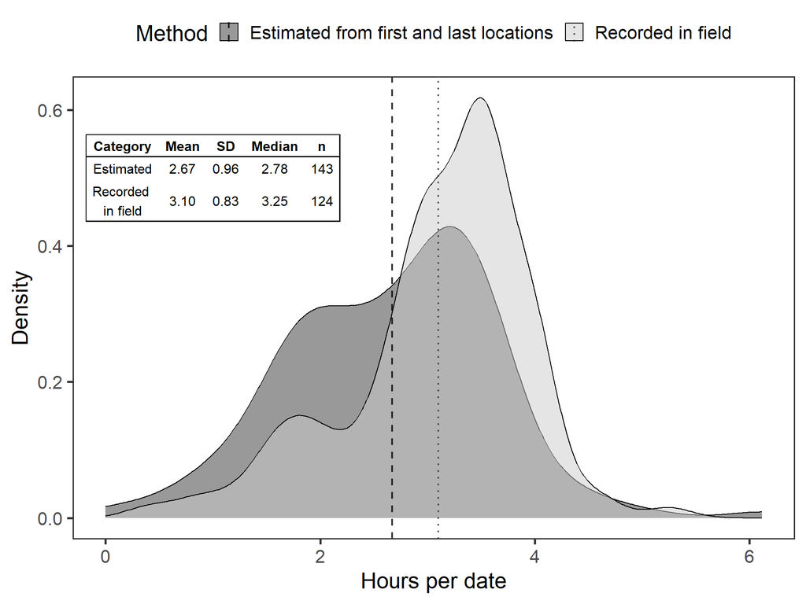

```r
effort_sum_pretty <- effort_sum %>%
  mutate(across(c(mean, sd, median), ~round(., 2))) %>%
  rename(Category = source, Mean = mean, SD = sd, Median = median) %>%
  mutate(Category = factor(Category, levels = c("First_last_locations", "Recorded_in_field"), labels = c("Estimated", "Recorded \nin field")))

#Is location-based start/end estimation lower than recorded observation times? I expect so, but let's visualize
library(gridExtra)
library(gtable)
library(grid)

#Overall - density plot
table_for_plot_effort <- tableGrob(effort_sum_pretty,
                                   rows = NULL,
                                   theme = ttheme_default(core = list(bg_params = list(fill = "white")), colhead = list(bg_params = list(fill = "white", col = "white"))))

#Add rectangle around table
table_for_plot_effort = gtable_add_grob(table_for_plot_effort, grobs = rectGrob(gp = gpar(fill = NA, lwd = 2)),
                                 t = 1, b = nrow(table_for_plot_effort), r = ncol(table_for_plot_effort), l = 1)
# dd line under column names
table_for_plot_effort = gtable_add_grob(table_for_plot_effort, grobs = rectGrob(gp = gpar(fill = NA, lwd = 2)),
                                  t = 1, l = 1, r = ncol(table_for_plot_effort))

obs_effort_density_plot <- ggplot(effort_all, aes(x = obs_effort, fill = source)) +
  geom_density(alpha = 0.5) +
  theme_bw(base_size = 20) +
  theme(panel.grid.minor = element_blank(), panel.grid.major = element_blank(), legend.position = "top") +
  geom_vline(data=effort_sum, aes(xintercept=mean, color=source, linetype=source), size = 0.75, alpha = 0.8) + #Add line for mean time at location
  scale_fill_grey(labels = c("Estimated from first and last locations", "Recorded in field")) +
  scale_color_manual(values = c("gray0", "gray20"), labels = c("Estimated from first and last locations", "Recorded in field")) + #Color is for lines. Make lines a little darker than fill colors
  scale_linetype_manual(values=c("dashed", "dotted"), labels = c("Estimated from first and last locations", "Recorded in field")) +
  labs(x = "Hours per date", y = "Density", color = "Method", fill = "Method", linetype = "Method") +
  annotation_custom(grob = table_for_plot_effort, xmin = 0, xmax = 2, ymin = .4, ymax = .6)

obs_effort_density_plot
```

Conclusion:

The different ways of calculating observation effort are pretty correlated, but not always. Likely makes the most sense to take the smallest and largest times out of recorded observation effort *AND* first/last telemetry points, as done above.

## Step 4: Check for missing effort

```r
#How much effort data are missing?
missing_effort <- exp_info %>%
  filter(priority == 1) %>%
  filter(!(date %in% effort_all$date)) %>%
  filter(!(year == 2016 & (patch == 204 | patch == 49))) %>% #Remove patches without tagged birds
  filter(!(year == 2017 & (patch == 137 | patch == 200))) #Remove patches without tagged birds
```

There are still dates where effort was not available. This could be because (a) nobody went out to do telemetry, or (b) people did telemetry but did not find the bird. Unfortunately I am not able to reconstruct what exactly happened; the observation effort here can therefore be considered a minimum amount.